# blogpost7

The_A+_team

2022-12-05

1. How are you continuing your exploratory data analysis?
- Our previous research only focus on five-year time period. So it’s diffuclt to see the obvious trend. As a result, we expand our datasets to ten-year range. But the airline dataset only has the data from 2014. So we still need to figure out how to explain the descrepancy of the datasets. Then, we are going to analyze the combined dataset of agriculture and airline.
- After we do the analysis on the relationship between agriculture, airline, and CO2 emission. We found that in some years the correlation was very weak. In order to make our data more convincing and thorough, we are going to incorporate new datasets into the previous research. After doing research, we think that GDP is a crucial indicator to influence the emission. The GDP dataset also includes the data of the US. population. So we choose to investigate the relationship between the GDP, population, and total emission.
- However, we only have the separate datasets of CO2 emission for agriculture sector and airline sector. So we still need a total emission datasets. We found the total emission dataset online and make a regression model based on these two datasets.

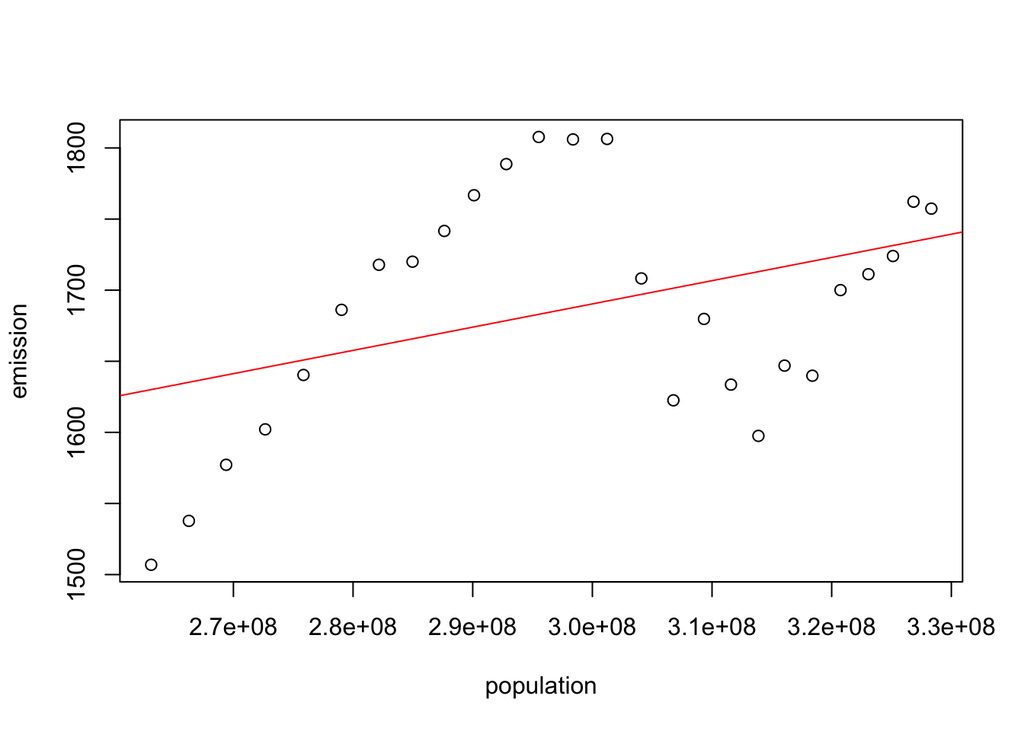

```r
library(here)
library(tidyverse)
library(dplyr)
library(ggplot2)
gdp_emission <- read_csv(here::here("dataset", "gdp_emission_clean.csv"), show_col_types = FALSE)
model <- lm(emission ~ population, data = gdp_emission)
plot(emission ~ population, data=gdp_emission)
abline(lm(emission ~ population, data=gdp_emission), col = "red")
```

```r
summary(model)
```

```
##
## Call:
## lm(formula = emission ~ population, data = gdp_emission)
##
## Residuals:
##      Min       1Q   Median       3Q      Max
## -123.177  -68.019   -8.949   56.063  124.710
##
## Coefficients:
##              Estimate Std. Error t value Pr(>|t|)
## (Intercept) 1.200e+03  2.307e+02   5.202 2.49e-05 ***
## population  1.634e-06  7.709e-07   2.120   0.0445 *
## ---
## Signif. codes:  0 '***' 0.001 '**' 0.01 '*' 0.05 '.' 0.1 ' ' 1
##
## Residual standard error: 77.9 on 24 degrees of freedom
## Multiple R-squared:  0.1578, Adjusted R-squared:  0.1227
## F-statistic: 4.495 on 1 and 24 DF,  p-value: 0.04452
```